# transitiontrees: A Complete, Interpreted Tutorial on the Grammar of AI Prompts

Every function explained and every result read, on a real log of student prompt-writing moves

transitiontrees

2026-06-17

# How to read this tutorial

`transitiontrees` fits a **variable-order prediction suffix tree** (Ron, Singer & Tishby 1996) and exposes a **pathway-centric API**. A fixed-order Markov chain assumes memory is the *same length everywhere* (“the last move predicts the next”, or “the last two do”). That is rarely true of behaviour. A variable-order tree lets the **data decide, per context, how much history matters** — some prompting moves are predictable from the single previous move, others only make sense given a longer run-up, and most longer histories add nothing and should be pruned away.

This document does two things at once:

1. **Walks every exported function** against a real **log of how students compose AI prompts** — each prompt decomposed into its ordered *rhetorical moves* (`Order`, `Context`, `Specify`, …).
2. **Interprets every result.** After each table, test, and plot there is a *Reading* block: what the numbers actually say about how these students build a prompt, what the method is doing under the hood, and — just as important — *what you should not over-read*.

A running storyline emerges and is worth stating up front so the sections connect rather than feel like a feature list:

> **The arc.** A prompt almost always *opens* with a command (`Order`) but its *body* is carried by `Specify` and `Context`. The single firmest rule in the corpus is grammatical: **after a `Context` move, students `Specify`** — the great majority of the time. The memory in this behaviour is **short** — prompts are only a few moves long, so cross-validation says order-2/3 is the ceiling and there is no deep structure to find. And the grammar **shifts over the course**: early assignments chain everything into `Specify`; later ones reorganise — a difference that is *statistically real*, whereas the same prompts split by **grade** show *no* difference at all. Every section below adds one piece of evidence to that arc.

Conventions:

- **Pathway** = a sequence of observed moves in arrow notation, `"A -> B -> C"` (leftmost = *oldest*).
- **Start** = the empty pathway (no history); `"(start)"` in tables, sentinel `"<root>"` internally. Its prediction is just the marginal “what move comes next on average”.
- All public tables are plain `data.frame`s; the four result classes (`transitiontrees`, `transitiontrees_bootstrap`, `transitiontrees_comparison`, `transitiontrees_tune`) all support `as.data.frame()`.

# The dataset

The raw file is in **long format**: one row per *move*, carrying the prompt it belongs to (`prompt_id`), the move’s order within that prompt (`value`), the move label (`name`), and a set of prompt-level covariates (the student `id.x`, the `assignment`, the `llm` used, the graded `performance`).

```r
raw <- read.csv(
  "/Users/mohammedsaqr/Documents/Documents X/DocumentsX/TNA Work/TNA networks teem data/Seqdatalonged.csv",
  stringsAsFactors = FALSE)
dim(raw)
```

```
#> [1] 726  17
```

```r
str(raw)
```

```
#> 'data.frame':    726 obs. of  17 variables:
#>  $ prompt_id     : chr  "1_1" "1_1" "1_1" "1_1" ...
#>  $ PrompptID     : int  1 1 1 1 2 2 2 2 2 2 ...
#>  $ Number        : int  1 1 1 1 1 1 1 1 2 2 ...
#>  $ id.x          : chr  "0ca6067370b98f981e8829d8d27349690ecc931e463d1c7a8d4d390914fafdf0" "0ca6067370b98f981e8829d8d27349690ecc931e463d1c7a8d4d390914fafdf0" "0ca6067370b98f981e8829d8d27349690ecc931e463d1c7a8d4d390914fafdf0" "0ca6067370b98f981e8829d8d27349690ecc931e463d1c7a8d4d390914fafdf0" ...
#>  $ assignment    : chr  "assignment1" "assignment1" "assignment1" "assignment1" ...
#>  $ llm           : chr  "ChatGPT 3.5" "ChatGPT 3.5" "ChatGPT 3.5" "ChatGPT 3.5" ...
#>  $ data          : chr  "No data" "No data" "No data" "No data" ...
#>  $ prompt        : chr  "I need a full table for interactions between the spread of diseases in a population indicating the source and t"| __truncated__ "I need a full table for interactions between the spread of diseases in a population indicating the source and t"| __truncated__ "I need a full …
#>  $ textsize      : int  187 187 187 187 590 590 590 590 112 112 ...
#>  $ initial_prompt: int  1 1 1 1 1 1 1 1 0 0 ...
#>  $ prompt_thread : int  0 0 0 0 0 0 0 0 1 1 ...
#>  $ id.y          : chr  "0ca6067370b98f981e8829d8d27349690ecc931e463d1c7a8d4d390914fafdf0" "0ca6067370b98f981e8829d8d27349690ecc931e463d1c7a8d4d390914fafdf0" "0ca6067370b98f981e8829d8d27349690ecc931e463d1c7a8d4d390914fafdf0" "0ca6067370b98f981e8829d8d27349690ecc931e463d1c7a8d4d390914fafdf0" ...
#>  $ performance   : chr  "high" "high" "high" "high" ...
#>  $ round_grade   : int  10 10 10 10 9 9 9 9 9 9 ...
#>  $ name          : chr  "Specify" "Context" "Request" "Order" ...
#>  $ value         : int  1 2 3 4 1 2 3 4 1 2 ...
#>  $ Sequence      : int  1 2 3 4 1 2 3 4 5 6 ...
```

```r
sort(table(raw$name), decreasing = TRUE)
```

```
#>
#>   Order Specify Context  Reject Request Approve
#>     249     237     110      59      58      13
```

> **Reading the corpus.** Six rhetorical moves, and they are unevenly used (the counts are in the table above). `Order` and `Specify` together are the clear majority of every move made; `Approve` is almost absent. This imbalance is the single most important fact about the data and it echoes through every later result: a model that just guesses “Order” or “Specify” will look deceptively good, so the interesting question is never “what is the modal next move” (usually one of those two) but “*which contexts overturn that default*”. Keep that lens for the rest of the tutorial.

The modelling unit is **one prompt** — `prompt_id` groups a prompt’s moves into one ordered sequence. `transitiontrees` ingests a long event log natively, so the fit can point straight at the columns: `actor = "prompt_id"` makes **each prompt one sequence**, `action = "name"` is the move label, and `order = "value"` puts a prompt’s moves in order. For the few places below that need the prompts as explicit sequences (per-prompt scoring in §8, the cohort split in §11), we also reshape the long log into a ragged list of sequences and a row-aligned table of prompt-level covariates with base R.

```r
seqs <- lapply(split(raw, raw$prompt_id),
               function(d) d$name[order(d$value)])   # one sequence per prompt
prompt_meta <- do.call(rbind, lapply(
  split(raw, raw$prompt_id),
  function(d) d[1, c("id.x", "assignment", "performance")]))  # row-aligned to seqs
length(seqs)                            # number of prompts
```

```
#> [1] 281
```

```r
str(head(seqs, 3))                      # ragged: each prompt its own length
```

```
#> List of 3
#>  $ 1_1 : chr [1:4] "Specify" "Context" "Request" "Order"
#>  $ 10_1: chr [1:3] "Order" "Context" "Specify"
#>  $ 10_2: chr [1:4] "Reject" "Request" "Order" "Specify"
```

```r
alphabet <- sort(unique(raw$name))      # the 6-move symbol space
alphabet
```

```
#> [1] "Approve" "Context" "Order"   "Reject"  "Request" "Specify"
```

```r
AI_data  <- seqs                                # ragged prompt sequences, used throughout
length(unique(prompt_meta$id.x))                # distinct students
```

```
#> [1] 49
```

```r
summary(lengths(seqs))                          # prompt lengths
```

```
#>    Min. 1st Qu.  Median    Mean 3rd Qu.    Max.
#>   1.000   2.000   3.000   2.584   3.000   4.000
```

```r
first_moves <- vapply(seqs, function(s) s[1], character(1))
sort(prop.table(table(first_moves)), decreasing = TRUE)  # OPENING move distribution
```

```
#> first_moves
#>      Order     Reject    Request    Specify    Approve    Context
#> 0.61565836 0.18505338 0.06761566 0.04982206 0.04626335 0.03558719
```

> **Reading the shape — and the first real finding.** Compare the *opening* move with the corpus frequencies above (what students *mostly do*). They disagree sharply: a prompt **opens with `Order`** far more often than `Order`’s one-third share of all moves — it is by far the commonest opening (see the printed opening distribution). That is a genuine behavioural signature: students *open* a prompt with a command (“build X”, “make Y”), then spend the body **specifying and contextualising** what they actually want. We have not fitted anything yet and the data already has structure. Prompts are also **very short** — the printed `summary()` of prompt lengths shows a low median and a short ceiling. That brevity is *why* pruning and cross-validation will matter: a depth-3 context simply cannot have much evidence behind it, because only a handful of prompts run that long.

# 1. Fitting a context tree: `context_tree()`

`context_tree()` is the constructor. It returns an S3 `transitiontrees`: a list of nodes keyed by pathway string, an edges table, the alphabet, and the hyperparameters. It accepts the long event log directly — `actor`/`action`/`order` name the columns and it reshapes internally — so no manual wide-format step is required. Because the deepest prompt is 4 moves, the deepest *context* worth asking for is 3 (it predicts the 4th move), so we cap `max_depth = 3`; with only a few hundred short prompts we keep `min_count` low so depth-2/3 contexts can form at all.

```r
tree <- context_tree(
  raw,                 # the long event log, read natively
  actor  = "prompt_id",# one sequence per prompt
  action = "name",     # the move label column
  order  = "value",    # move order within a prompt
  max_depth = 3L,      # longest context the tree may represent
  min_count = 3L,      # a context needs >= 3 occurrences to get its own node
  smoothing = "floor"  # default: floor MLE at ymin=0.001 and renormalise
)
tree
```

```
#> <transitiontrees>  24 nodes, depth <= 3, 6 states  [unpruned]
#>   alphabet : Approve, Context, Order, Reject, Request, Specify
#>   fit on   : 281 sequences, 726 observations
#>   smoothing: floor(ymin=0.001, rule=interpolate)   min_count = 3
#> (start)   n=726    -> Order (0.34)
#> |-- Approve   n=13     -> Order (0.77)
#> |-- Context   n=87     -> Specify (0.89)
#> |   |-- Order     n=74     -> Specify (0.98)
#> |   |   `-- Request   n=4      -> Specify (0.99)
#> |   `-- Specify   n=3      -> Order (0.66)
#> |-- Order     n=194    -> Specify (0.55)
#> |   |-- Approve   n=10     -> Specify (0.80)
#> |   |-- Context   n=3      -> Request (0.66)
#> |   |-- Reject    n=14     -> Specify (0.92)
#> |   `-- Request   n=17     -> Specify (0.76)
#> |       `-- Reject    n=4      -> Specify (0.99)
#> |-- Reject    n=56     -> Specify (0.55)
#> |   `-- Request   n=3      -> Order (0.99)
#> |-- Request   n=32     -> Order (0.75)
#> |   |-- Context   n=3      -> Order (0.66)
#> |   |-- Order     n=3      -> Specify (0.99)
#> |   `-- Reject    n=5      -> Order (0.99)
#> `-- Specify   n=63     -> Request (0.38)
#>     |-- Context   n=18     -> Request (0.77)
#>     |   `-- Order     n=14     -> Request (0.99)
#>     |-- Order     n=24     -> Context (0.71)
#>     |   `-- Request   n=4      -> Context (0.99)
#>     `-- Reject    n=9      -> Order (0.77)
```

> **Reading the fit.** Three numbers matter in that banner. **24 nodes** — far fewer than the AI-session trees you may have seen, precisely because the prompts are short: there are only so many distinct 2- and 3-move histories that occur >= 3 times. **281 sequences / 726 observations** — every prompt with >= 1 move is kept. With *no* history the best guess is `Order` at 0.34, barely ahead of `Specify` (0.33); that near-tie is the baseline every deeper context has to *beat*. Hold that thought — §3 and §4 are the machinery for separating the rules that beat it from the spines that merely repeat.

The two things you actually reach for — how many contexts the tree holds, and the root marginal — both have clean accessors, no list-spelunking required:

```r
n_nodes(tree)                    # how many contexts the tree holds
```

```
#> [1] 24
```

```r
query_pathway(tree, "(start)")    # the root marginal = the null model
```

```
#>    Approve    Context      Order     Reject    Request    Specify
#> 0.01790634 0.15151515 0.34297521 0.08126722 0.07988981 0.32644628
```

> **Reading the root marginal.** `query_pathway(tree, "(start)")` is the next-move distribution with *no* history (printed above): `Order` and `Specify` nearly tied at the top, `Context` next, the rest trailing. This vector is the **null model** for the entire analysis — “divergence from parent”, G² pruning, and bootstrap “informativeness” all ultimately measure *how far a context’s prediction departs from a chain of these marginals*.

## 1.1 Input shapes accepted

The long log above is one of several equivalent front doors. The same prompts can also arrive as a wide character matrix or a ragged list; state-sequence (`stslist`) objects and fitted transition/network objects are accepted too, auto-detected by their S3 class.

For *these* prompts every route below is numerically identical; the `stslist` and network-object lines are illustrative of the other input shapes `context_tree()` accepts:

```r
# Equivalent front doors for THESE prompts (all give the same tree):
context_tree(raw, actor = "prompt_id", action = "name", order = "value")
context_tree(seqs)                          # the same prompts as a ragged list

# A state-sequence (stslist) object is read directly too:
context_tree(engagement, max_depth = 2L)

# transitiontrees also accepts a fitted transition/network object directly,
# auto-detected by its S3 class:
# context_tree(my_network_object, max_depth = 2L)
```

> **Reading the input rule.** The input shape is a convenience, never a numerical fork — every route to *these* prompts gives the same tree. Reading the long log directly with `actor = "prompt_id"`, `order = "value"` makes **each prompt one sequence**; handing `context_tree()` a fitted transition/network object instead lets the network and the tree share one symbol space, auto-detected from the object’s class. The hard boundary, by design: a **pure graph** object with no underlying sequences — an aggregated transition network — is *rejected*, because the original move sequences cannot be recovered from edge weights. Numeric matrices are likewise rejected (they mean “transition matrix” elsewhere). *transitiontrees fits on sequences, never on aggregated transitions.*

## 1.2 The five smoothing schemes

Smoothing decides what probability an *unseen* next-move gets. With a skewed 6-move alphabet and very short prompts, many context × move cells are zero, so this choice is not cosmetic.

`compare_smoothing()` fits the tree under every scheme — holding `max_depth`/`min_count` fixed — and returns the comparison in one call:

```r
compare_smoothing(seqs, max_depth = 3L, min_count = 3L)
```

| smoothing | n_nodes | perplexity |
| --- | --- | --- |
| floor | 24 | 2.756734 |
| laplace | 24 | 2.952349 |
| kneser_ney | 24 | 2.800799 |
| witten_bell | 24 | 2.785255 |
| jelinek_mercer | 24 | 3.207483 |

# 2. Inspecting the tree

## 2.1 `summary()` — tidy node table + scalars

```r
summary(tree)
```

```
#> <transitiontrees summary>  24 nodes, depth <= 3, 6 states  [unpruned]
#>
#>             pathway depth count likely_next next_probability divergence
#>             (start)     0   726       Order        0.3429752         NA
#>               Order     1   194     Specify        0.5492371  0.8816161
#>             Context     1    87     Specify        0.8921724  1.0746190
#>             Specify     1    63     Request        0.3796667  1.1101873
#>              Reject     1    56     Specify        0.5512500  0.4331304
#>             Request     1    32       Order        0.7465000  0.6738563
#>             Approve     1    13       Order        0.7656154  0.6988270
#>    Order -> Context     2    74     Specify        0.9815676  0.1104970
#>    Order -> Specify     2    24     Context        0.7050833  0.5941452
#>  Context -> Specify     2    18     Request        0.7741111  0.7405598
#>  changes_prediction
#>                  NA
#>                TRUE
#>                TRUE
#>                TRUE
#>                TRUE
#>               FALSE
#>               FALSE
#>               FALSE
#>                TRUE
#>               FALSE
#> # ... 14 more rows (use as.data.frame(tree) for the full table)
```

## 2.2 `as.data.frame(tree)` — uniform tidy-extract

```r
df <- as.data.frame(tree)
head(df, 6)
```

|  | pathway | depth | count | likely_next | next_probability | divergence | changes_prediction |
| --- | --- | --- | --- | --- | --- | --- | --- |
| 1 | (start) | 0 | 726 | Order | 0.3429752 | NA | NA |
| 2 | Order | 1 | 194 | Specify | 0.5492371 | 0.8816161 | TRUE |
| 3 | Context | 1 | 87 | Specify | 0.8921724 | 1.0746190 | TRUE |
| 4 | Order -> Context | 2 | 74 | Specify | 0.9815676 | 0.1104970 | FALSE |
| 5 | Specify | 1 | 63 | Request | 0.3796667 | 1.1101873 | TRUE |
| 6 | Reject | 1 | 56 | Specify | 0.5512500 | 0.4331304 | TRUE |

```r
all.equal(df, tree_pathways(tree))
```

```
#> [1] TRUE
```

> **Reading it.** `TRUE` — `as.data.frame(tree)` *is* `tree_pathways(tree)`; one source of truth, no schema drift between the console object and the tidy table you would put in a manuscript.

## 2.3 Model-fit scalars

`model_fit()` bundles all the standard fit scalars into one tidy row:

```r
model_fit(tree)
```

| logLik | df | nobs | AIC | BIC | perplexity |
| --- | --- | --- | --- | --- | --- |
| -736.198 | 120 | 726 | 1712.396 | 2262.902 | 2.756734 |

> **Reading the scalars.** Perplexity is the interpretable one: “effective number of equally-likely next moves”. The uniform baseline is 6 (six moves, no knowledge); the fitted tree is 2.76 — knowing the recent moves collapses six possibilities to under three. That is a large, real effect, but it is *in-sample* and the depth-3 tree is mildly over-parameterised, so read it as an upper-optimistic bound. AIC/BIC exist to *penalise* node count; §10’s cross-validation gives the honest, out-of-sample figure.

# 3. The pathway-centric API

Five exports return pathways as tidy data.frames sharing one schema: `pathway | depth | count | likely_next | next_probability | divergence | changes_prediction`.

## 3.1 `tree_pathways()` — every node, sorted

```r
pw <- tree_pathways(tree)
nrow(pw); head(pw)
```

```
#> [1] 24
```

|  | pathway | depth | count | likely_next | next_probability | divergence | changes_prediction |
| --- | --- | --- | --- | --- | --- | --- | --- |
| 1 | (start) | 0 | 726 | Order | 0.3429752 | NA | NA |
| 2 | Order | 1 | 194 | Specify | 0.5492371 | 0.8816161 | TRUE |
| 3 | Context | 1 | 87 | Specify | 0.8921724 | 1.0746190 | TRUE |
| 4 | Order -> Context | 2 | 74 | Specify | 0.9815676 | 0.1104970 | FALSE |
| 5 | Specify | 1 | 63 | Request | 0.3796667 | 1.1101873 | TRUE |
| 6 | Reject | 1 | 56 | Specify | 0.5512500 | 0.4331304 | TRUE |

> **Reading it.** Default sort is `count` descending, so the top rows (printed above) are the corpus’s *highways*: the root, then the single moves `Order` and `Context`, then `Order -> Context`. That last one is interesting already — a large share of prompts issue a command and then add context, and that 2-move history points almost deterministically onward. Frequency surfaces the *workflow*; the next two functions surface what is *informative*.

Schema is stable on empty results, and other sorts/filters work:

```r
str(tree_pathways(tree, min_count = 1e6))   # 0 rows, still 7 typed cols
```

```
#> 'data.frame':    0 obs. of  7 variables:
#>  $ pathway           : chr
#>  $ depth             : int
#>  $ count             : num
#>  $ likely_next       : chr
#>  $ next_probability  : num
#>  $ divergence        : num
#>  $ changes_prediction: logi
```

```r
head(tree_pathways(tree, sort_by = "divergence"), 4)
```

|  | pathway | depth | count | likely_next | next_probability | divergence | changes_prediction |
| --- | --- | --- | --- | --- | --- | --- | --- |
| 1 | Specify -> Context | 2 | 3 | Order | 0.6636667 | 3.225360 | TRUE |
| 2 | Context -> Order | 2 | 3 | Request | 0.6636667 | 2.657276 | TRUE |
| 3 | Order -> Request | 2 | 3 | Specify | 0.9950000 | 2.640811 | TRUE |
| 4 | Request -> Reject | 2 | 3 | Order | 0.9950000 | 1.459811 | TRUE |

```r
head(tree_pathways(tree, sort_by = "depth", decreasing = FALSE), 4)
```

|  | pathway | depth | count | likely_next | next_probability | divergence | changes_prediction |
| --- | --- | --- | --- | --- | --- | --- | --- |
| 1 | (start) | 0 | 726 | Order | 0.3429752 | NA | NA |
| 2 | Specify | 1 | 63 | Request | 0.3796667 | 1.1101873 | TRUE |
| 3 | Context | 1 | 87 | Specify | 0.8921724 | 1.0746190 | TRUE |
| 4 | Request | 1 | 32 | Order | 0.7465000 | 0.6738563 | FALSE |

> **Reading it.** The empty case still returns the 7 typed columns — so downstream `rbind`/joins never break on a thresholded-away result. Re-sorting by `divergence` previews §3.3: the high-divergence rows are *different* pathways from the high-count rows — the contexts that *matter* are not the ones that are *common*.

## 3.2 `common_pathways()` — top-n by frequency

```r
common_pathways(tree, top = 8)
```

|  | pathway | depth | count | likely_next | next_probability | divergence | changes_prediction |
| --- | --- | --- | --- | --- | --- | --- | --- |
| 1 | (start) | 0 | 726 | Order | 0.3429752 | NA | NA |
| 2 | Order | 1 | 194 | Specify | 0.5492371 | 0.8816161 | TRUE |
| 3 | Context | 1 | 87 | Specify | 0.8921724 | 1.0746190 | TRUE |
| 4 | Order -> Context | 2 | 74 | Specify | 0.9815676 | 0.1104970 | FALSE |
| 5 | Specify | 1 | 63 | Request | 0.3796667 | 1.1101873 | TRUE |
| 6 | Reject | 1 | 56 | Specify | 0.5512500 | 0.4331304 | TRUE |
| 7 | Request | 1 | 32 | Order | 0.7465000 | 0.6738563 | FALSE |
| 8 | Order -> Specify | 2 | 24 | Context | 0.7050833 | 0.5941452 | TRUE |

```r
common_pathways(tree, top = 5, depth = 2L)
```

|  | pathway | depth | count | likely_next | next_probability | divergence | changes_prediction |
| --- | --- | --- | --- | --- | --- | --- | --- |
| 4 | Order -> Context | 2 | 74 | Specify | 0.9815676 | 0.1104970 | FALSE |
| 8 | Order -> Specify | 2 | 24 | Context | 0.7050833 | 0.5941452 | TRUE |
| 9 | Context -> Specify | 2 | 18 | Request | 0.7741111 | 0.7405598 | FALSE |
| 10 | Request -> Order | 2 | 17 | Specify | 0.7611176 | 0.1682754 | FALSE |
| 11 | Reject -> Order | 2 | 14 | Specify | 0.9240000 | 0.7658238 | FALSE |

> **Reading it.** The top order-2 contexts are all `*-> Specify` or `Order -> Context`: the second move is highly predictable once you know the first. That the *frequent* 2-move histories are so deterministic is itself evidence for short, strong, local grammar — §10 makes the trade-off formal.

## 3.3 `divergent_pathways()` — top-n by KL from parent

```r
divergent_pathways(tree, top = 8)
```

|  | pathway | depth | count | likely_next | next_probability | divergence | changes_prediction |
| --- | --- | --- | --- | --- | --- | --- | --- |
| 1 | Specify -> Context | 2 | 3 | Order | 0.6636667 | 3.2253597 | TRUE |
| 2 | Context -> Order | 2 | 3 | Request | 0.6636667 | 2.6572760 | TRUE |
| 3 | Order -> Request | 2 | 3 | Specify | 0.9950000 | 2.6408106 | TRUE |
| 4 | Request -> Reject | 2 | 3 | Order | 0.9950000 | 1.4598108 | TRUE |
| 5 | Specify | 1 | 63 | Request | 0.3796667 | 1.1101873 | TRUE |
| 6 | Context | 1 | 87 | Specify | 0.8921724 | 1.0746190 | TRUE |
| 7 | Reject -> Specify | 2 | 9 | Order | 0.7741111 | 1.0625406 | TRUE |
| 8 | Order | 1 | 194 | Specify | 0.5492371 | 0.8816161 | TRUE |

```r
divergent_pathways(tree, flips_only = TRUE, top = 8)
```

|  | pathway | depth | count | likely_next | next_probability | divergence | changes_prediction |
| --- | --- | --- | --- | --- | --- | --- | --- |
| 1 | Specify -> Context | 2 | 3 | Order | 0.6636667 | 3.2253597 | TRUE |
| 2 | Context -> Order | 2 | 3 | Request | 0.6636667 | 2.6572760 | TRUE |
| 3 | Order -> Request | 2 | 3 | Specify | 0.9950000 | 2.6408106 | TRUE |
| 4 | Request -> Reject | 2 | 3 | Order | 0.9950000 | 1.4598108 | TRUE |
| 5 | Specify | 1 | 63 | Request | 0.3796667 | 1.1101873 | TRUE |
| 6 | Context | 1 | 87 | Specify | 0.8921724 | 1.0746190 | TRUE |
| 7 | Reject -> Specify | 2 | 9 | Order | 0.7741111 | 1.0625406 | TRUE |
| 8 | Order | 1 | 194 | Specify | 0.5492371 | 0.8816161 | TRUE |

> **Reading the flippers.** Restricting to `changes_prediction = TRUE` keeps pathways where the longer history *overturns which move is most likely*, not merely sharpens it. Essentially the whole high-KL list survives — these divergences are genuine redirections. If this table had come back **empty**, the correct conclusion would have been “the tree only sharpens, never redirects” — a real, reportable negative. It is not empty, so these are the pathways to investigate, prune *toward*, and bootstrap in §12 — once we have filtered the count-3 noise out.

## 3.4 `sharp_pathways()` — top-n by predictive sharpness

```r
sharp_pathways(tree, top = 8)
```

|  | pathway | depth | count | likely_next | next_probability | divergence | changes_prediction |
| --- | --- | --- | --- | --- | --- | --- | --- |
| 1 | Order -> Context -> Specify | 3 | 14 | Request | 0.9950000 | 0.35255140 | FALSE |
| 2 | Reject -> Request | 2 | 5 | Order | 0.9950000 | 0.39863574 | FALSE |
| 3 | Reject -> Request -> Order | 3 | 4 | Specify | 0.9950000 | 0.37676838 | FALSE |
| 4 | Request -> Order -> Context | 3 | 4 | Specify | 0.9950000 | 0.01565966 | FALSE |
| 5 | Request -> Order -> Specify | 3 | 4 | Context | 0.9950000 | 0.48623377 | FALSE |
| 6 | Request -> Reject | 2 | 3 | Order | 0.9950000 | 1.45981079 | TRUE |
| 7 | Order -> Request | 2 | 3 | Specify | 0.9950000 | 2.64081059 | TRUE |
| 8 | Order -> Context | 2 | 74 | Specify | 0.9815676 | 0.11049698 | FALSE |

> **Reading it — and a deliberate trap.** Sorted by `next_probability` descending, the top rows hit near-1.0 probabilities and look like near-deterministic rules. **Do not believe the low-`count` ones.** A 3-move context seen a handful of times that always continued the same way is exactly what a tree manufactures by chance. The rows that *are* trustworthy carry real support — `Order -> Context -> Specify` and its parent `Order -> Context`, both with high `count` in the table above. Same constructive routine, now with enough prompts behind it to take seriously. The lesson this table teaches is *why* §6 and §12 exist: sharpness without support is noise, and the package gives you formal tools to tell them apart rather than eyeballing `next_probability`.

# 4. Per-context diagnostics: `tree_dependence()`

This is the full information-theoretic decomposition that `prune_tree(criterion = "KL")` thresholds: per context its `divergence`, its entropy `entropy`, its parent’s `entropy_before`, the resolved uncertainty `entropy_drop = entropy_before - entropy`, and the modal-flip flag (`changes_prediction`).

```r
tree_dependence(tree, sort_by = "entropy_drop", top = 8)
```

|  | pathway | depth | count | divergence | entropy | entropy_before | entropy_drop | likely_next | likely_before | changes_prediction |
| --- | --- | --- | --- | --- | --- | --- | --- | --- | --- | --- |
| 1 | Context | 1 | 87 | 1.0746190 | 0.61444602 | 2.158692 | 1.5442465 | Specify | Order | TRUE |
| 2 | Request -> Reject | 2 | 3 | 1.4598108 | 0.05702433 | 1.346147 | 1.2891224 | Order | Specify | TRUE |
| 3 | Approve | 1 | 13 | 0.6988270 | 1.02630649 | 2.158692 | 1.1323860 | Order | Order | FALSE |
| 4 | Request | 1 | 32 | 0.6738563 | 1.08430760 | 2.158692 | 1.0743849 | Order | Order | FALSE |
| 5 | Reject -> Request | 2 | 5 | 0.3986357 | 0.05702433 | 1.084308 | 1.0272833 | Order | Order | FALSE |
| 6 | Order -> Request | 2 | 3 | 2.6408106 | 0.05702433 | 1.084308 | 1.0272833 | Specify | Order | TRUE |
| 7 | Order | 1 | 194 | 0.8816161 | 1.27855918 | 2.158692 | 0.8801333 | Specify | Order | TRUE |
| 8 | Context -> Specify | 2 | 18 | 0.7405598 | 0.80777284 | 1.681187 | 0.8734137 | Request | Request | FALSE |

> **Reading the decomposition.** `entropy_drop` answers “how much next-move uncertainty does this history *remove*?” **`Context` tops the table**: its parent (the root) is very uncertain over the six moves, and conditioning on a single `Context` move almost determines the next one (low `entropy`). It also *flips* the modal move from `Order` to `Specify`. That is the most valuable kind of context — it both sharpens and redirects, with a high `count` of support. The low-`count` rows below it show large `entropy_drop` too, but read them as candidates, not conclusions.

```r
head(tree_dependence(tree, base = exp(1)), 4)   # nats instead of bits
```

|  | pathway | depth | count | divergence | entropy | entropy_before | entropy_drop | likely_next | likely_before | changes_prediction |
| --- | --- | --- | --- | --- | --- | --- | --- | --- | --- | --- |
| 1 | Specify -> Context | 2 | 3 | 2.235649 | 0.66582192 | 0.4259015 | -0.2399204 | Order | Specify | TRUE |
| 2 | Context -> Order | 2 | 3 | 1.841883 | 0.66582192 | 0.8862297 | 0.2204078 | Request | Specify | TRUE |
| 3 | Order -> Request | 2 | 3 | 1.830470 | 0.03952626 | 0.7515848 | 0.7120585 | Specify | Order | TRUE |
| 4 | Request -> Reject | 2 | 3 | 1.011864 | 0.03952626 | 0.9330778 | 0.8935515 | Order | Specify | TRUE |

# 5. Specific-pathway lookup

The examples below use two concrete contexts from this alphabet: a single move, and a two-move history written both ways `query_pathway()` accepts — an arrow-string and a character vector.

```r
d1  <- "Context"               # a depth-1 context
d2  <- "Order -> Context"      # a depth-2 context, arrow form
d2v <- c("Order", "Context")   # the same context, vector form
```

## 5.1 `query_pathway()` — look up a single pathway

```r
query_pathway(tree, d2)    # arrow-string form
```

```
#>    Approve    Context      Order     Reject    Request    Specify
#> 0.00100000 0.00100000 0.00100000 0.00100000 0.01443243 0.98156757
```

```r
query_pathway(tree, d2v)   # same context, vector form
```

```
#>    Approve    Context      Order     Reject    Request    Specify
#> 0.00100000 0.00100000 0.00100000 0.00100000 0.01443243 0.98156757
```

> **Reading it.** Both call shapes (arrow-string and character vector) return the same conditional distribution over the six moves for the most-common depth-2 context, `Order -> Context`. Read it as a probabilistic rule: after a command then a context move, the next move is `Specify` with probability 0.98 — the constructive routine made explicit.

```r
query_pathway(tree, d1, next_state = "Specify")
```

```
#> [1] 0.8921724
```

> **Reading it.** Pinning `next_state` returns a single number: `P(Specify | last move = Context)` = 0.89. This is the primitive you use to answer targeted questions (“after a context move, how likely is a specify move?”) without pulling the whole vector.

```r
deep_ctx <- c("Reject", "Approve", "Context")   # a 3-deep context unlikely to be a node
query_pathway(tree, deep_ctx)                # default: longest-suffix backoff
```

```
#>    Approve    Context      Order     Reject    Request    Specify
#> 0.00100000 0.00100000 0.06955172 0.00100000 0.03527586 0.89217241
```

```r
query_pathway(tree, deep_ctx, exact = TRUE)  # strict: all NA if not a node
```

```
#> Approve Context   Order  Reject Request Specify
#>      NA      NA      NA      NA      NA      NA
```

> **Reading the backoff.** This contrast is the model’s whole philosophy in two lines. By default an unseen 3-deep context **backs off to its longest matching suffix** (here `Context`) — exactly what makes a *variable*-order model robust: it never refuses to predict, it just uses as much history as it has evidence for. `exact = TRUE` returns all-`NA` for the same query, because that precise 3-gram was never a node. Use the default for prediction; use `exact = TRUE` only when auditing *which* contexts literally exist in the tree.

## 5.2 `pathway_exists()` — boolean check

```r
pathway_exists(tree, d1)
```

```
#> [1] TRUE
```

```r
pathway_exists(tree, d2)
```

```
#> [1] TRUE
```

```r
pathway_exists(tree, "nonsense -> path")
```

```
#> [1] FALSE
```

> **Reading it.** `TRUE/TRUE/FALSE`. The third is `FALSE` not because prediction failed but because that literal context is not a node — the membership test does *not* do suffix backoff, by design. It answers “did the tree learn this exact context”, the right question for structure audits and test scaffolding.

## 5.3 `subtree()` — restrict to descendants

```r
sub <- subtree(tree, d1)         # prints "subtree of: Context" in its banner
sub
```

```
#> <transitiontrees>  4 nodes, depth <= 3, 6 states  [unpruned]
#>   alphabet : Approve, Context, Order, Reject, Request, Specify
#>   fit on   : 281 sequences, 726 observations
#>   smoothing: floor(ymin=0.001, rule=interpolate)   min_count = 3
#>   subtree of: Context
```

```r
head(tree_pathways(sub), 4)
```

|  | pathway | depth | count | likely_next | next_probability | divergence | changes_prediction |
| --- | --- | --- | --- | --- | --- | --- | --- |
| 1 | Context | 1 | 87 | Specify | 0.8921724 | NA | NA |
| 2 | Order -> Context | 2 | 74 | Specify | 0.9815676 | 0.11049698 | FALSE |
| 3 | Request -> Order -> Context | 3 | 4 | Specify | 0.9950000 | 0.01565966 | FALSE |
| 4 | Specify -> Context | 2 | 3 | Order | 0.6636667 | 3.22535972 | TRUE |

> **Reading it.** You get a new, self-contained `transitiontrees` rooted at `Context` containing only that move and everything growing out of it, with the global arrow-form names preserved and the local root shown in its banner. Use this to drill into one motif — “everything that happens after a context move” — and run the *same* pathway API on the slice.

# 6. Pruning: `prune_tree()`

Pruning removes contexts that **don’t earn their depth**: bottom-up, a leaf whose evidence doesn’t beat its parent under the chosen criterion is dropped, the parent re-tested, and so on. The root is never pruned.

`compare_pruning()` applies each criterion — holding `alpha`/`threshold` fixed — and reports how hard each one trims, in one call:

```r
compare_pruning(tree)
```

| criterion | n_nodes | reduction_pct |
| --- | --- | --- |
| G2 | 15 | 37.5 |
| KL | 24 | 0.0 |
| AIC | 15 | 37.5 |
| BIC | 15 | 37.5 |

> **Reading the criteria.** The unpruned tree had 24 nodes (the `n_nodes` column above is each criterion’s surviving size). The likelihood-ratio rules agree tightly: **`G2`, `AIC` and `BIC` all cut it to about the same smaller tree**, while `KL` at the lenient 0.005-nat threshold keeps everything (any tiny divergence clears the bar — a knob, not a verdict; tighten `threshold` to make it bite). The contrast with a deep AI-session tree is instructive: there G² typically removes the large majority of nodes because long contexts overgrow wildly; **here it removes far less, because the prompts are so short there was little overgrowth to begin with.** The depth-3 contexts that exist are mostly the low-`count` ones, and those are exactly what G²/AIC/BIC strip. **Practical guidance: use `G2` (or `AIC`); report the reduction, because “the unjustified contexts were the rare deep ones” is itself the short-memory finding.**

```r
pr_strict <- prune_tree(tree, criterion = "G2", alpha = 0.001)
pr_strict   # banner reports node count + "pruned by: G2  alpha = 0.001"
```

```
#> <transitiontrees>  6 nodes, depth <= 3, 6 states  [pruned]
#>   alphabet : Approve, Context, Order, Reject, Request, Specify
#>   fit on   : 281 sequences, 726 observations
#>   smoothing: floor(ymin=0.001, rule=interpolate)   min_count = 3
#>   pruned by: G2   alpha = 0.001
#> (start)   n=726    -> Order (0.34)
#> |-- Context   n=87     -> Specify (0.89)
#> |-- Order     n=194    -> Specify (0.55)
#> |-- Reject    n=56     -> Specify (0.55)
#> |-- Request   n=32     -> Order (0.75)
#> `-- Specify   n=63     -> Request (0.38)
```

> **Reading it.** Dropping `alpha` 0.05 → 0.001 raises the χ² bar, so even fewer contexts survive. The banner now reports the criterion and `alpha`, and those settings *travel with the tree* so `compare_trees()` re-applies the identical prune to every permutation refit (a correctness detail in §11).

```r
pruned <- prune_tree(tree, criterion = "G2", alpha = 0.05)
n_nodes(pruned)
```

```
#> [1] 15
```

> **Reading it.** This 15-node `pruned` tree is the **defensible model** and the working object for the rest of the tutorial: prediction, comparison, bootstrap and plots all use it, because the dropped contexts were the unsupported deep ones.

# 7. Re-smoothing a fitted tree: `smooth_tree()`

Smoothing is applied once at fit time, but `smooth_tree()` re-smooths a fitted tree under a new scheme **without re-counting**:

```r
pruned_kn <- smooth_tree(pruned, "kneser_ney")     # one scheme
c(original = n_nodes(pruned), re_smoothed = n_nodes(pruned_kn))  # topology unchanged
```

```
#>    original re_smoothed
#>          15          15
```

Handed a **fitted tree**, `compare_smoothing()` sweeps every scheme by re-smoothing (not refitting), so the whole §1.2 comparison works on the pruned model in one call:

```r
compare_smoothing(pruned)
```

| smoothing | n_nodes | perplexity |
| --- | --- | --- |
| floor | 15 | 2.817779 |
| laplace | 15 | 2.940387 |
| kneser_ney | 15 | 2.854876 |
| witten_bell | 15 | 2.845051 |
| jelinek_mercer | 15 | 3.303120 |

> **Reading it.** Counts and topology are frozen — `n_nodes` is constant down the table — and only the `prob` vectors change, so perplexity moves a little while the *tree* is identical. (Contrast §1.2, where `compare_smoothing()` was given raw data and *refit* under each scheme.) This is the right tool for a smoothing sweep on an already-fit, already-pruned model — you are tuning how unseen moves are handled, not refitting structure.

# 8. Prediction surface

## 8.1 `predict.transitiontrees()`

Schema-stable rule: **container inputs (list/data.frame/matrix) always return a matrix**; a bare character vector returns a named vector.

```r
predict(pruned, newdata = list(d2v, c("Order"), c("Reject", "Request")))
```

```
#>      Approve   Context  Order     Reject    Request   Specify
#> [1,]   0.001 0.0010000 0.0010 0.00100000 0.01443243 0.9815676
#> [2,]   0.001 0.4006495 0.0010 0.01637113 0.03174227 0.5492371
#> [3,]   0.001 0.0010000 0.7465 0.09418750 0.00100000 0.1563125
```

```r
predict(pruned, newdata = d2v)
```

```
#>    Approve    Context      Order     Reject    Request    Specify
#> 0.00100000 0.00100000 0.00100000 0.00100000 0.01443243 0.98156757
```

```r
predict(pruned, newdata = list(d2v, c("Order","Context"), c("Reject")),
        type = "class")
```

```
#> [1] "Specify" "Specify" "Specify"
```

> **Reading it.** The matrix form (one row per history, one column per move) is for batch scoring; the named-vector shortcut is for interactive one-offs. `type = "class"` collapses each row to its modal move — and on this data those will lean toward `Specify` after any `Context`-bearing history and `Order` at the root, the predictable consequence of the grammar. When an exact context is missing from the pruned tree, prediction backs off to the longest matching suffix (same philosophy as §5.1), which is why this compact pruned tree still scores arbitrary new prompts.

## 8.2 `perplexity()`, `score_sequences()`, `score_positions()`

The scoring surface measures how well the model predicts a corpus. The numbers here score the prompts the tree was fit on, so they are the *optimistic* bound; the honest out-of-sample figure is the cross-validation in §10 — no hand-rolled train/test split required.

```r
perplexity(pruned)
```

```
#> [1] 2.817779
```

> **Reading it.** Perplexity is the “effective number of equally-likely next moves”. The uniform baseline is 6 (six moves, no knowledge); the pruned tree scores 2.82, so knowing the recent history collapses six possibilities to under three. This is in-sample and therefore optimistic; §10 gives the cross-validated figure to report.

`score_sequences()` breaks that one number down to one row per prompt:

```r
ss <- score_sequences(pruned, newdata = AI_data)
ss
```

| sequence_id | n_scored | log_lik | perplexity |
| --- | --- | --- | --- |
| 1 | 4 | -3.568700 | 2.440432 |
| 2 | 3 | -2.003370 | 1.949923 |
| 3 | 4 | -5.812325 | 4.276270 |
| 4 | 2 | -1.669322 | 2.304033 |
| 5 | 1 | -1.070097 | 2.915663 |
| 6 | 3 | -3.506744 | 3.218498 |
| 7 | 2 | -1.669322 | 2.304033 |
| 8 | 3 | -2.003370 | 1.949923 |
| 9 | 2 | -2.174723 | 2.966437 |
| 10 | 3 | -2.003370 | 1.949923 |

[output cut: 271 more lines]

> **Reading it.** One row per prompt with its own perplexity. Most prompts follow the common grammar and are predicted well; a tail is genuinely surprising — the worst prompt scores 19 against a median of 2.6. Those high-perplexity prompts are where unusual rhetorical strategies live, worth qualitative follow-up.

`score_positions(worst =)` zooms to the individual moves the model predicts worst:

```r
score_positions(pruned, newdata = AI_data, worst = 5)
```

| sequence_id | position | matched_context | observed | predicted_prob | log_lik |
| --- | --- | --- | --- | --- | --- |
| 83 | 3 | Order -> Context | Request | 0.01443243 | -4.238277 |
| 27 | 2 | Order | Reject | 0.01637113 | -4.112236 |
| 131 | 2 | Order | Reject | 0.01637113 | -4.112236 |
| 149 | 2 | Order | Reject | 0.01637113 | -4.112236 |
| 77 | 2 | Specify | Reject | 0.01677778 | -4.087700 |

> **Reading the worst predictions.** Each row is one observed move with the `matched_context` that drove its prediction, ranked by `predicted_prob` ascending — *where the model was most blindsided*: rare moves landing where the dominant `Order`/`Specify` machinery expected its usual successors. Diagnostic gold for which transitions more data would need to capture.

## 8.3 `model_fit()` — every fit scalar at once

`model_fit()` bundles the goodness-of-fit scalars into one tidy row, so log-likelihood, the parameter count, AIC, BIC and perplexity come from a single call:

```r
model_fit(pruned)
```

| logLik | df | nobs | AIC | BIC | perplexity |
| --- | --- | --- | --- | --- | --- |
| -752.099 | 75 | 726 | 1654.198 | 1998.264 | 2.817779 |

> **Reading it.** Per-observation log-likelihood (`logLik / nobs`) is just `-log(perplexity)` on the information scale that AIC/BIC tooling expects. AIC and BIC penalise the 15-node count, so they are the right scalars to weigh two candidate trees fit on the same data.

# 9. Sequence generation

## 9.1 `generate_sequences()`

```r
gen <- generate_sequences(pruned, n = 5L, length = 4L)
gen
```

```
#>      [,1]      [,2]      [,3]      [,4]
#> [1,] "Order"   "Specify" "Context" "Request"
#> [2,] "Reject"  "Order"   "Request" "Specify"
#> [3,] "Context" "Specify" "Order"   "Context"
#> [4,] "Order"   "Specify" "Context" "Request"
#> [5,] "Specify" "Request" "Order"   "Specify"
```

## 9.2 `simulate.transitiontrees()`

```r
sim <- simulate(pruned, nsim = 5L, seed = 42L, length = 4L)
sim
```

```
#>      [,1]      [,2]      [,3]      [,4]
#> [1,] "Request" "Order"   "Specify" "Request"
#> [2,] "Request" "Order"   "Context" "Specify"
#> [3,] "Order"   "Specify" "Request" "Order"
#> [4,] "Reject"  "Order"   "Specify" "Context"
#> [5,] "Specify" "Context" "Order"   "Request"
```

> **Reading it.** The R-standard `simulate()` generic wrapping `generate_sequences()` with `nsim` + a `seed` for reproducibility — same draws as seeding `generate_sequences()` by hand. Use this form so your simulation slots into the usual `stats` workflow.

# 10. Cross-validated tuning: `tune_tree()`

k-fold CV over a hyperparameter grid; returns a `transitiontrees_tune` data.frame sorted by held-out perplexity, with the winner on `attr(., "best")`.

```r
tg <- tune_tree(AI_data, max_depth = 1L:3L, min_count = c(3L, 5L),
                    smoothing = c("floor","kneser_ney"),
                    prune = c(FALSE, TRUE), folds = 5L, seed = 1L)
head(tg, 8); attr(tg, "best")
```

|  | max_depth | nmin | smoothing | prune | logLik | n_scored | perplexity | n_nodes_avg | folds_failed |
| --- | --- | --- | --- | --- | --- | --- | --- | --- | --- |
| 1 | 3 | 3 | kneser_ney(discount=0.75) | FALSE | -800.8798 | 726 | 3.013615 | 21.4 | 0 |
| 2 | 3 | 5 | kneser_ney(discount=0.75) | FALSE | -803.5200 | 726 | 3.024594 | 15.0 | 0 |
| 3 | 2 | 3 | kneser_ney(discount=0.75) | FALSE | -805.9642 | 726 | 3.034794 | 17.8 | 0 |
| 4 | 2 | 5 | kneser_ney(discount=0.75) | FALSE | -807.1735 | 726 | 3.039853 | 14.0 | 0 |
| 5 | 3 | 3 | floor(ymin=0.001, rule=interpolate) | FALSE | -808.4490 | 726 | 3.045199 | 21.4 | 0 |
| 6 | 3 | 5 | floor(ymin=0.001, rule=interpolate) | FALSE | -811.7570 | 726 | 3.059106 | 15.0 | 0 |
| 7 | 2 | 3 | floor(ymin=0.001, rule=interpolate) | FALSE | -813.9330 | 726 | 3.068288 | 17.8 | 0 |
| 8 | 2 | 5 | floor(ymin=0.001, rule=interpolate) | FALSE | -815.3874 | 726 | 3.074441 | 14.0 | 0 |

|  | max_depth | nmin | smoothing | prune | logLik | n_scored | perplexity | n_nodes_avg | folds_failed |
| --- | --- | --- | --- | --- | --- | --- | --- | --- | --- |
| 1 | 3 | 3 | kneser_ney(discount=0.75) | FALSE | -800.8798 | 726 | 3.013615 | 21.4 | 0 |

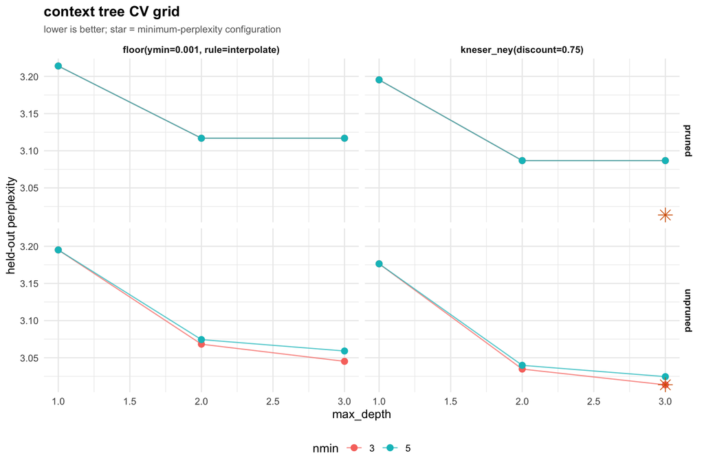

```r
plot(tg)
```

# 11. Two-cohort comparison

`compare_trees()` asks whether two cohorts generate *significantly different* pathway dynamics: a count-weighted symmetric-KL distance plus a permutation null from shuffling prompt → cohort labels. The natural question for a *course* log is whether the grammar of a prompt **matures over time**, so we split on `assignment`: **early** (1–2) vs **late** (4–5).

We don’t subset by hand: `context_tree(..., group =)` fits **one tree per cohort** in a single call (over a shared alphabet), returning a `transitiontrees_group`. `prune_tree()` prunes the whole group, and `compare_trees()` takes the 2-group result directly. We fit at `max_depth = 2` because each cohort is smaller.

```r
stage   <- ifelse(prompt_meta$assignment %in% c("assignment1", "assignment2"),
                  "early", "late")
cohorts <- prune_tree(
  context_tree(seqs, max_depth = 2L, min_count = 3L, group = stage),
  criterion = "G2", alpha = 0.05)
cohorts
```

```
#> <transitiontrees_group>  2 groups
#>   early            9 nodes, depth <= 2, 153 seq, 406 obs  [pruned]
#>   late             8 nodes, depth <= 2, 128 seq, 320 obs  [pruned]
```

```r
tree_early <- cohorts$early; tree_late <- cohorts$late
```

## 11.1 `tree_distance()`

```r
tree_distance(tree_early, tree_late)
```

```
#> [1] 0.1212616
```

```r
tree_distance(tree_early, tree_late, symmetric = FALSE)
```

```
#> [1] 0.09072513
```

> **Reading it.** A single count-weighted symmetric-KL number (0.121) — meaningful only against a null (next), but note `symmetric = FALSE` gives a *different* value: `D(early‖late) ≠ D(late‖early)`, because a pathway frequent early but absent late contributes differently than the reverse. Use the asymmetric form when you specifically care about “what does late do that early can’t account for”.

## 11.2 `compare_trees()`

```r
cmp <- compare_trees(cohorts, iter = 200L, seed = 1L)  # 2-group -> pairwise
class(cmp); cmp
```

```
#> [1] "transitiontrees_comparison"
```

```
#> <transitiontrees_comparison>  iter = 200
#>   observed distance : 0.121
#>   null mean         : 0.0627
#>   p-value           : 0.0149
#>
#> top divergent pathways:
#>             pathway count_a count_b divergence_ab divergence_ba divergence_sym
#>  Context -> Specify      13       0         1.032         2.387          1.710
#>   Reject -> Specify       6       0         0.639         2.009          1.324
#>    Order -> Specify      18       0         0.532         1.926          1.229
#>             Approve       0       9         1.573         0.726          1.150
#>             Context      43      44         0.147         0.550          0.348
#>              Reject      33      23         0.179         0.188          0.183
```

> **Reading the test — a real result.** Observed distance **0.121**, permutation-null mean **0.063**, **p = 0.015**. The observed separation sits well above what random relabelling produces, and clears the 0.05 bar: **the grammar of a prompt changes materially between early and late assignments.** The breakdown table below says *how*: early prompts funnel almost everything into a `Specify` move, while command-then-context (`Order -> Context`) and acknowledgement (`Approve`) show up far more in the late cohort. The reading: early-course prompting is a blunt “say it, then specify it” reflex; later prompting reorganises into command-then-contextualise and starts using acknowledgement moves. Students don’t just prompt more; they prompt *with a different grammar* as they gain expertise.

```r
head(as.data.frame(cmp), 8)
```

|  | pathway | count_a | count_b | divergence_ab | divergence_ba | divergence_sym |
| --- | --- | --- | --- | --- | --- | --- |
| 1 | Context -> Specify | 13 | 0 | 1.0324784 | 2.38693734 | 1.70970788 |
| 2 | Reject -> Specify | 6 | 0 | 0.6392727 | 2.00915845 | 1.32421558 |
| 3 | Order -> Specify | 18 | 0 | 0.5318667 | 1.92636814 | 1.22911744 |
| 4 | Approve | 0 | 9 | 1.5733007 | 0.72575595 | 1.14952834 |
| 5 | Context | 43 | 44 | 0.1469460 | 0.54994137 | 0.34844368 |
| 6 | Reject | 33 | 23 | 0.1787218 | 0.18773927 | 0.18323056 |
| 7 | Specify | 40 | 23 | 0.1319384 | 0.21502839 | 0.17348341 |
| 8 | Order -> Context | 0 | 33 | 0.1369440 | 0.04348605 | 0.09021503 |

> **Reading the breakdown.** `count_a`/`count_b` are the raw cohort counts; the asymmetry is stark (some pathways are almost entirely early or almost entirely late — compare the two count columns above). `divergence_ab`/`divergence_ba`/`divergence_sym` quantify the Kullback-Leibler divergence each way. A row with a large count gap *and* large `divergence_sym` genuinely distinguishes the cohorts — those are the rows to quote, not the small-count ones whose KL is large only because a near-zero denominator inflates it.

```r
## The same machinery on a split that does NOT separate: grade.
## A per-prompt grouping vector selects the cohort.
by_grade <- prune_tree(
  context_tree(seqs, max_depth = 2L, min_count = 3L,
               group = prompt_meta$performance),
  criterion = "G2", alpha = 0.05)
cmp_perf <- compare_trees(by_grade, iter = 200L, seed = 1L)
c(early_vs_late_p = cmp$p_value, high_vs_low_p = cmp_perf$p_value)
```

```
#> early_vs_late_p   high_vs_low_p
#>      0.01492537      0.17910448
```

> **Reading the contrast — why the negative result matters.** Run the *identical* test on high- vs low-`performance` prompts and the result is **p = 0.18** — set against the early/late **p = 0.015**, the grade split does not clear the 0.05 bar. This is the honest other half of the finding: the grammar of a prompt is shaped by **where in the course** it was written, but **not** by the grade it earned. A package that only ever returned “significant” would be useless; the value here is that it cleanly *fails to reject* when the structure isn’t there. Report both: the maturation effect is real precisely because the grade effect, tested the same way, is not.

## 11.3 `plot.transitiontrees_comparison()`

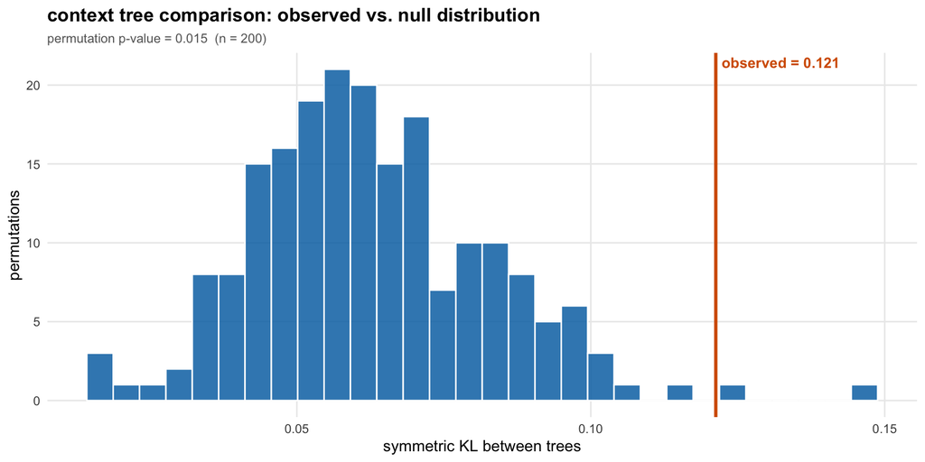

```r
plot(cmp)
```

# 12. Bootstrap reliability: `bootstrap_pathways()`

`prune_tree()` asked “which pathways pass a criterion *in this one dataset*?”. The bootstrap asks the stricter question: “which pass *reproducibly* under resampling?” Per pathway: **`stability`** (its count is reproducible within a tolerance band) and **`informative_rate`** (its G² vs parent reproducibly clears χ²). A pathway worth trusting is **both**.

```r
boot <- bootstrap_pathways(pruned, iter = 200L, stat = "count",
          seed = 1L, keep_resamples = TRUE)
boot
```

```
#> <transitiontrees_bootstrap>  200 resamples
#>   stability  : count in [0.50, 1.50] x observed, p < 0.05
#>   informative: G^2 > qchisq(0.95, df=k-1) = 11.07, threshold 0.80
#>   pathways   : 15 total, 10 stable, 8 informative, 8 both
#>
#> top pathways (stable + informative first):
#>             pathway depth count p_stability stability_rate stable
#>               Order     1   194       0.005          1.000   TRUE
#>             Context     1    87       0.005          1.000   TRUE
#>             Specify     1    63       0.005          1.000   TRUE
#>              Reject     1    56       0.005          1.000   TRUE
#>             Request     1    32       0.005          1.000   TRUE
#>    Order -> Specify     2    24       0.010          0.995   TRUE
#>  Context -> Specify     2    18       0.035          0.970   TRUE
#>     Reject -> Order     2    14       0.035          0.970   TRUE
#>             (start)     0   726       0.005          1.000   TRUE
#>    Order -> Context     2    74       0.005          1.000   TRUE
#>  informative_rate informative mean_G2 ci_G2_lo ci_G2_hi
#>             1.000        TRUE 244.675  220.616  271.873
#>             1.000        TRUE 134.694  104.056  170.600
#>             1.000        TRUE 100.891   74.014  127.689
#>             1.000        TRUE  37.008   26.155   48.513
#>             1.000        TRUE  32.695   19.352   50.240
#>             0.985        TRUE  20.232   11.383   30.020
#>             0.955        TRUE  18.618    9.901   26.992
#>             0.905        TRUE  16.509    9.240   24.168
#>                NA       FALSE     NaN       NA       NA
#>             0.645       FALSE  12.898    4.558   21.689
#> # ... 5 more pathways (use summary(x) for full table)
```

> **Reading the quadrants — the trust filter.** Of the 15 pruned pathways, 10 are **stable**, 8 **informative**, and 8 **both**. That last number is the one to internalise: only a handful of pathways in this entire corpus are simultaneously reproducible and predictively distinctive. The “both” set is five single-move pathways plus three depth-2 rules (`Order -> Specify`, `Context -> Specify`, `Reject -> Order`). Everything else — including the low-`count` high-divergence rows that §3.3 dangled in front of us — is not safe to build a narrative on. The depth-1 backbone is rock solid (huge, certain G²); the surviving depth-2 rules are the interesting ones because they cleared a much higher bar.

## 12.1 The summary table

```r
bs <- summary(boot)
bs[, c("pathway","depth","count","likely_next","next_probability",
       "divergence","changes_prediction","stable","informative",
       "stability_rate","informative_rate")]
```

| pathway | depth | count | likely_next | next_probability | divergence | changes_prediction | stable | informative | stability_rate | informative_rate |
| --- | --- | --- | --- | --- | --- | --- | --- | --- | --- | --- |
| Order | 1 | 194 | Specify | 0.5515464 | 0.9040449 | TRUE | TRUE | TRUE | 1.000 | 1.000 |
| Context | 1 | 87 | Specify | 0.8965517 | 1.1053662 | TRUE | TRUE | TRUE | 1.000 | 1.000 |
| Specify | 1 | 63 | Request | 0.3809524 | 1.1316643 | TRUE | TRUE | TRUE | 1.000 | 1.000 |
| Reject | 1 | 56 | Specify | 0.5535714 | 0.4569584 | TRUE | TRUE | TRUE | 1.000 | 1.000 |
| Request | 1 | 32 | Order | 0.7500000 | 0.6998237 | FALSE | TRUE | TRUE | 1.000 | 1.000 |
| Order -> Specify | 2 | 24 | Context | 0.7083333 | 0.6103707 | TRUE | TRUE | TRUE | 0.995 | 0.985 |
| Context -> Specify | 2 | 18 | Request | 0.7777778 | 0.7581046 | FALSE | TRUE | TRUE | 0.970 | 0.955 |
| Reject -> Order | 2 | 14 | Specify | 0.9285714 | 0.7841067 | FALSE | TRUE | TRUE | 0.970 | 0.905 |
| (start) | 0 | 726 | Order | 0.3429752 | NA | NA | TRUE | FALSE | 1.000 | NA |
| Order -> Context | 2 | 74 | Specify | 0.9864865 | 0.1177856 | FALSE | TRUE | FALSE | 1.000 | 0.645 |

[output cut: 5 more lines]

> **Reading it.** First 7 columns are the canonical schema (so this table joins cleanly to every other one); then the flags and bootstrap stats. The pathway to single out is **`Context -> Specify`**: across §3.3 (high KL with support), §3.4 (high sharpness with real support), §4 (top `entropy_drop`) and now here it survives as `stable` *and* `informative`. That convergence of evidence across four independent diagnostics is what lets you state it as a finding: *after a student adds context to a prompt, a specification move follows reproducibly.* That is the tutorial’s strongest second-order claim, and it is earned, not eyeballed.

```r
grep("^(mean|sd|ci)_", names(bs), value = TRUE)
```

```
#>  [1] "mean_count"             "sd_count"               "ci_count_lo"
#>  [4] "ci_count_hi"            "mean_next_probability"  "sd_next_probability"
#>  [7] "ci_next_probability_lo" "ci_next_probability_hi" "mean_divergence"
#> [10] "sd_divergence"          "ci_divergence_lo"       "ci_divergence_hi"
#> [13] "mean_G2"                "sd_G2"                  "ci_G2_lo"
#> [16] "ci_G2_hi"
```

> **Reading it.** Every tracked stat (`count`, `next_probability`, `divergence`, `G2`) carries a symmetric `mean/sd/ci_lo/ci_hi` quartet — so you can report a bootstrap CI for any pathway statistic, not just a point estimate. Quote `ci_*` bounds in a paper; never the bare point.

## 12.2 `keep_resamples = FALSE`

```r
boot_lean <- bootstrap_pathways(pruned, iter = 200L, seed = 1L,
                                keep_resamples = FALSE)
c(full = object.size(boot), lean = object.size(boot_lean))
```

```
#>   full   lean
#> 119288  15368
```

> **Reading it.** Same `iter`, a fraction of the memory — the raw `iter x pathway` resample matrices are dropped on the lean object. The summary table is unaffected; you only lose the ability to draw §12.4’s histograms (the plotter errors helpfully if you try). Use this for big `iter` in production; keep the default when you still want the distributions.

## 12.3 `plot.transitiontrees_bootstrap()`

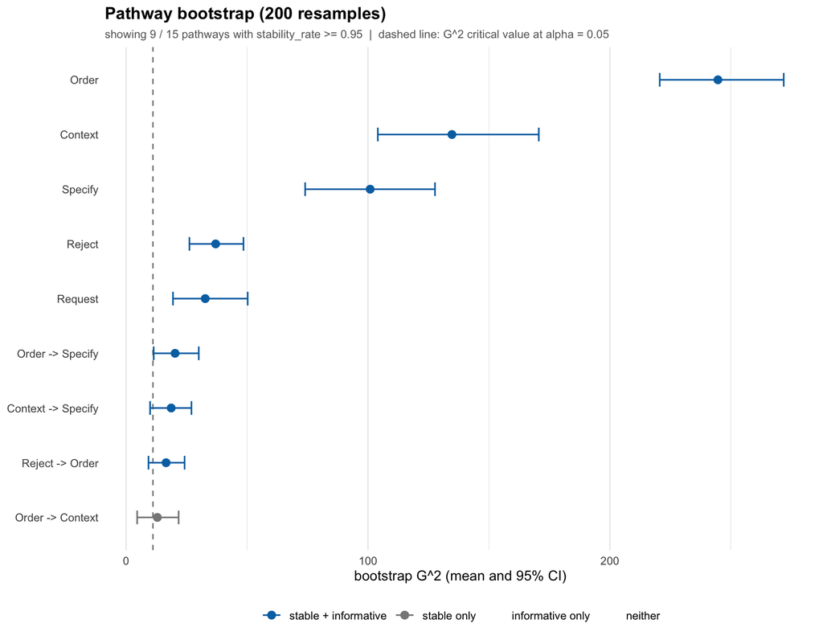

```r
plot(boot, top = 15)
```

## 12.4 `plot_pathway_resamples()`

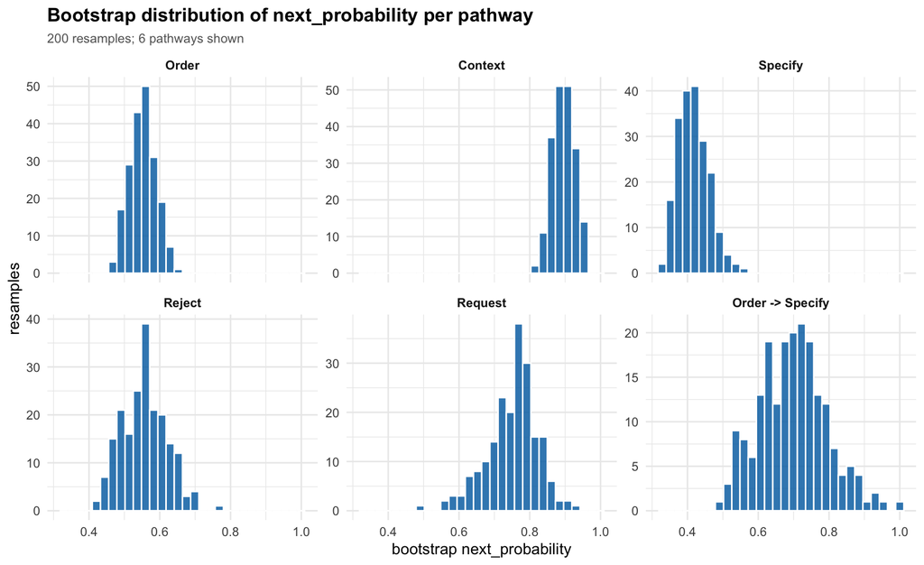

```r
plot_pathway_resamples(boot, stat = "next_probability", top = 6L)
```

> **Reading the histograms.** One panel per top pathway, the full bootstrap distribution of `next_probability`. Shape matters: a tight, symmetric peak means the estimate is well-determined; a **bimodal or heavy-tailed** panel is the tell that the pathway is *carrier-driven* — a handful of prompts (or students) account for it, and dropping them in a resample collapses it. For any pathway you intend to claim, check its panel here is unimodal and tight before you trust the point estimate from §3.

# 13. Visualization

In every static style: **node fill** = last move of the pathway, **node size** = context count, **edge thickness** = the child’s count (the volume of prompts flowing down that branch).

## 13.1a Horizontal phylogram (default)

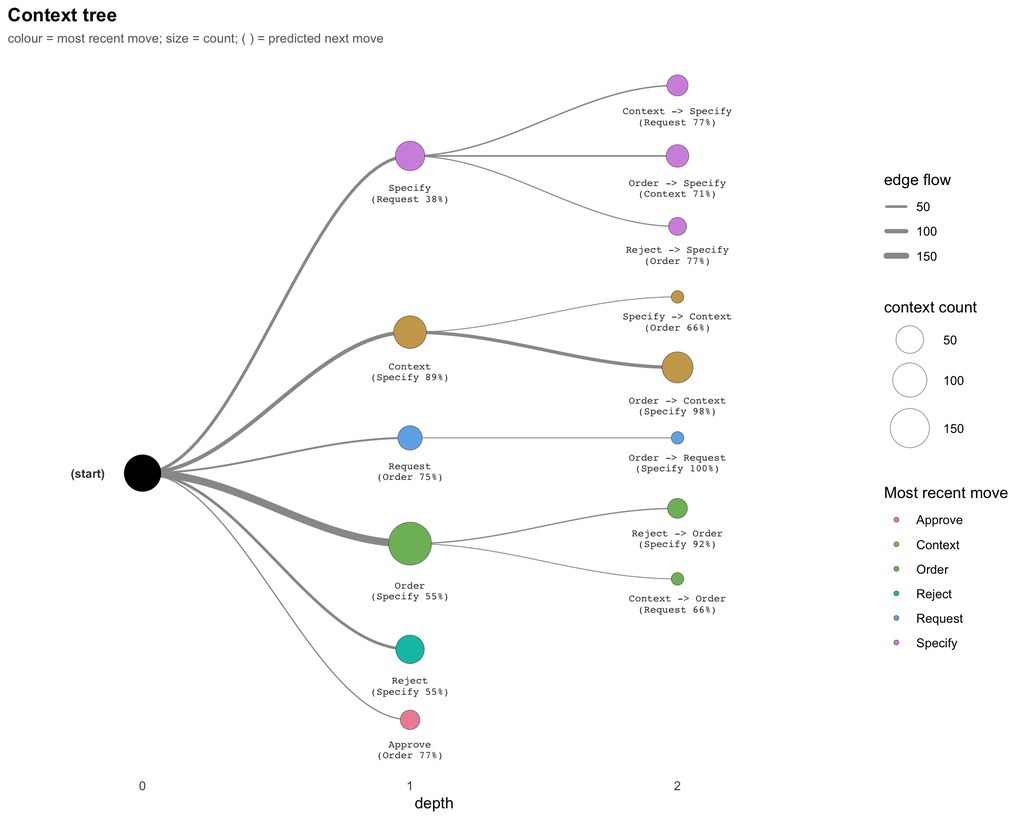

```r
plot(pruned)
```

> **Reading it.** `(start)` on the left, depth rightward along smooth curved branches, every leaf labelled with its **full arrow-form pathway**. This is the default style and the layout to use in a paper when you need to *cite specific pathways inline* — the reader can trace `Context -> Specify` to its leaf and read its encodings without decoding a circular layout. The thick `Order` and `Context` branches are the corpus highways; the thin outer twigs are contexts the G² prune *kept on evidence, not volume*.

## 13.1b Radial dendrogram

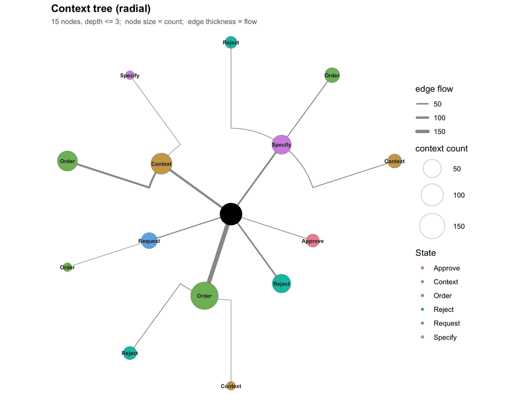

```r
plot(pruned, style = "dendrogram")
```

> **Reading the picture.** The eye should go to the thick edges near the centre: the high-volume `Order` and `Context` branches — the corpus highways. The thin outer twigs are the contexts the G² prune *kept on evidence, not volume*. The visual tension between a few fat central branches and a sparse fringe *is* the dataset’s story in one image: most prompt-writing is a short command-then-specify reflex; the structure lives in the first two moves.

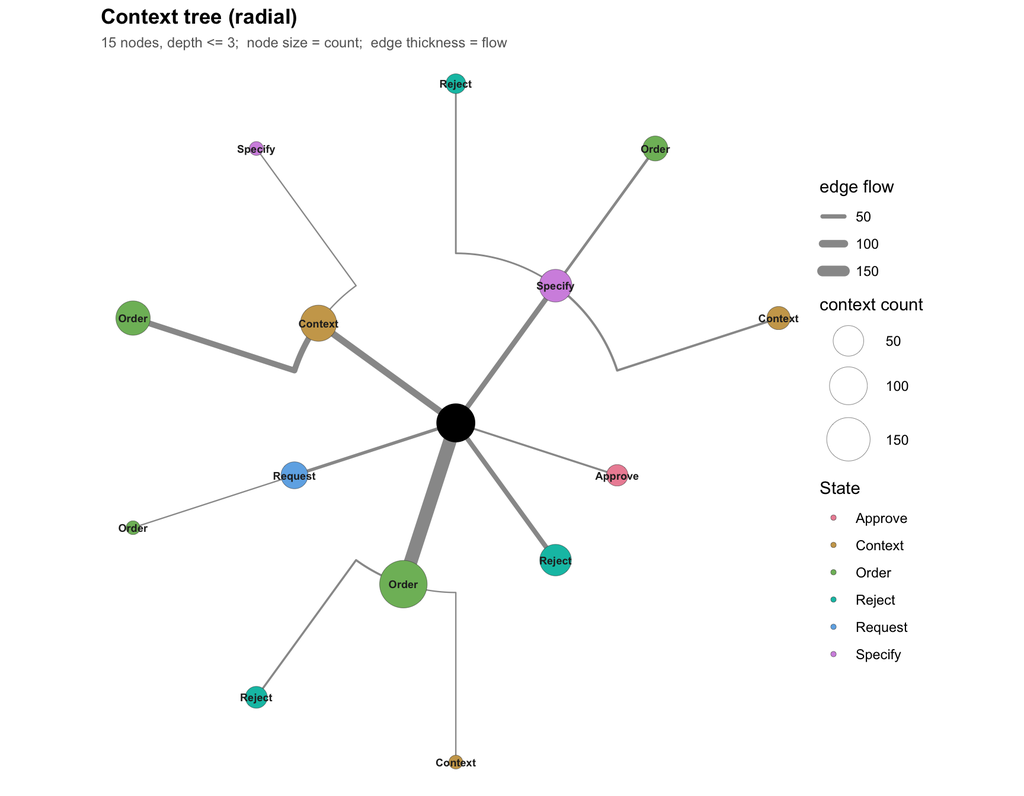

```r
plot(pruned, style = "dendrogram",
     point_size_range = c(4, 14), edge_size_range = c(0.4, 4))
```

> **Reading it.** Identical topology, exaggerated size dynamic range — for slides/posters where the count contrast needs to read from the back of a room. Encodings unchanged; only the scales differ.

## 13.1c Circular icicle (sunburst)

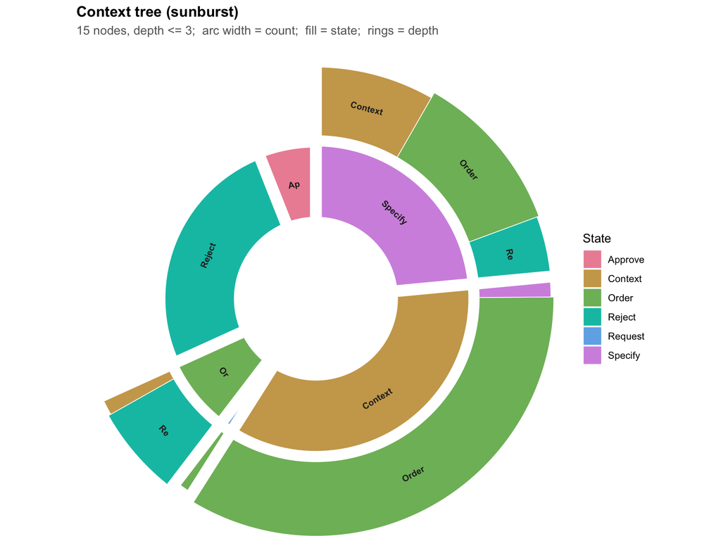

```r
plot(pruned, style = "icicle")
```

## 13.2 `plot_pathways()` — pathway × next-move heatmap

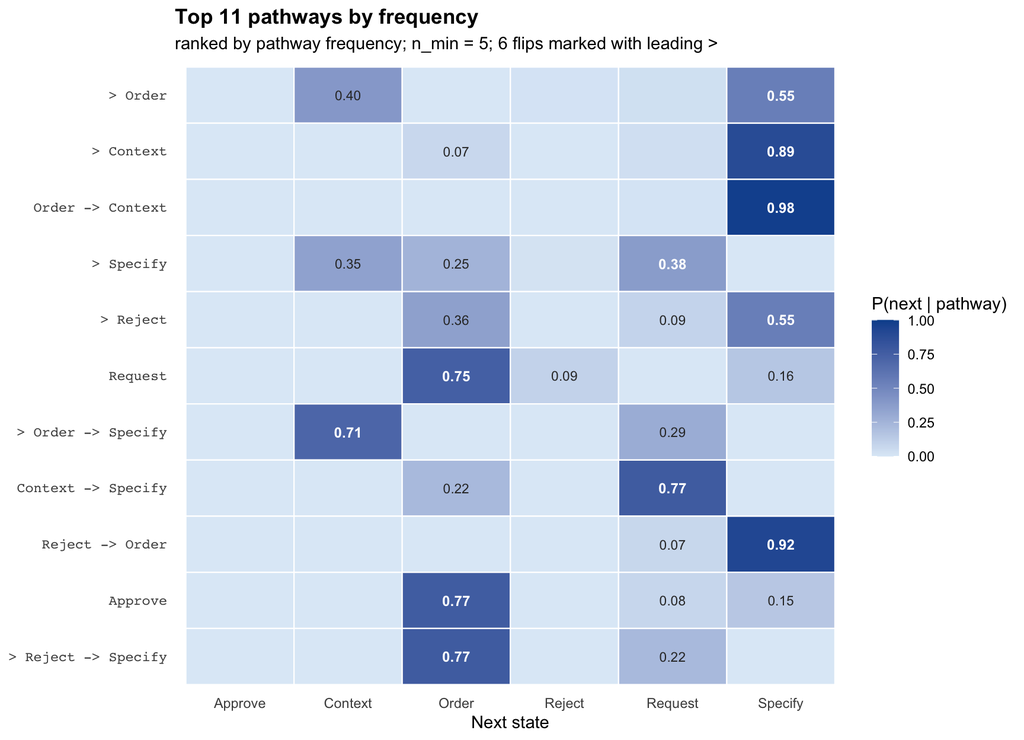

```r
plot_pathways(pruned, top = 12L, sort_by = "count")
```

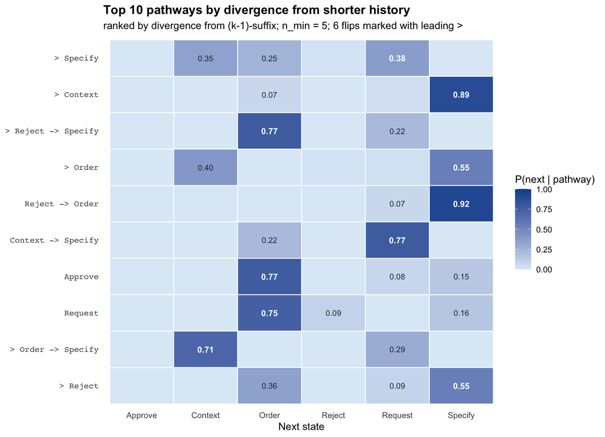

```r
plot_pathways(pruned, top = 10L, sort_by = "divergence", min_count = 5L)
```

> **Reading the two heatmaps together.** This is the single best “interpretation” figure. Sorted by **count**, the heatmap concentrates on the `Order`/`Specify` columns — the monolithic default workflow, visually. Sorted by **KL** (with `min_count` to kill small-sample noise), the bright cells *move*: `Context`-bearing rows light up the `Specify` column and `Order` lights up off-diagonal. That shift, side by side, is the entire thesis in one comparison — *common ≠ informative*. The `>` prefix marks modal-flip pathways: rows where history doesn’t just sharpen but redirects.

## 13.3 `plot_divergence()` — KL lollipop

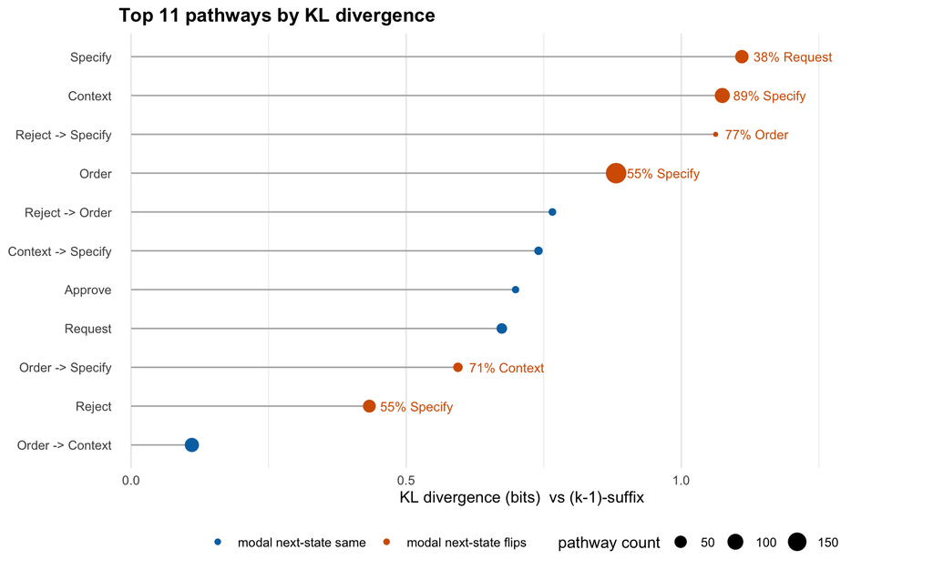

```r
plot_divergence(pruned, top = 12L, min_count = 5L)
```

> **The numbers in plain language.** Each pathway carries a few numbers; read them as separate dials:

> | Column | In two words | What it tells you |
> | --- | --- | --- |
> | `count` | *how common* | how often this history actually happened |
> | `divergence` (KL) | *history matters* | does remembering this step change the guess? |
> | `likely_next` | *best guess* | the single most likely next move |
> | `next_probability` | *how certain* | how confident that best guess is |
> | `changes_prediction` | *guess flips* | the best guess actually changed (orange) |

> The two that get conflated are **“history matters” (KL)** and **“how certain” (next_probability)** — they are independent. `Specify` is high on *history matters* (1.11) yet low on *how certain* (38%): remembering it changes the guess a lot, but you are still not sure. `Context` is high on both. Always read them as two dials, not one.

# 14. Uniform tidy-extract recap

```r
str(as.data.frame(pruned), give.attr = FALSE)
```

```
#> 'data.frame':    15 obs. of  7 variables:
#>  $ pathway           : chr  "(start)" "Order" "Context" "Order -> Context" ...
#>  $ depth             : int  0 1 1 2 1 1 1 2 2 2 ...
#>  $ count             : int  726 194 87 74 63 56 32 24 18 14 ...
#>  $ likely_next       : chr  "Order" "Specify" "Specify" "Specify" ...
#>  $ next_probability  : num  0.343 0.549 0.892 0.982 0.38 ...
#>  $ divergence        : num  NA 0.882 1.075 0.11 1.11 ...
#>  $ changes_prediction: logi  NA TRUE TRUE FALSE TRUE TRUE ...
```

```r
str(as.data.frame(boot),   give.attr = FALSE)
```

```
#> 'data.frame':    15 obs. of  30 variables:
#>  $ pathway               : chr  "Order" "Context" "Specify" "Reject" ...
#>  $ depth                 : int  1 1 1 1 1 2 2 2 0 2 ...
#>  $ count                 : int  194 87 63 56 32 24 18 14 726 74 ...
#>  $ likely_next           : chr  "Specify" "Specify" "Request" "Specify" ...
#>  $ next_probability      : num  0.552 0.897 0.381 0.554 0.75 ...
#>  $ divergence            : num  0.904 1.105 1.132 0.457 0.7 ...
#>  $ changes_prediction    : logi  TRUE TRUE TRUE TRUE FALSE TRUE ...
#>  $ G2                    : num  243.1 133.3 98.8 35.5 31 ...
#>  $ p_stability           : num  0.00498 0.00498 0.00498 0.00498 0.00498 ...
#>  $ stability_rate        : num  1 1 1 1 1 0.995 0.97 0.97 1 1 ...
#>  $ stable                : logi  TRUE TRUE TRUE TRUE TRUE TRUE ...
#>  $ informative_rate      : num  1 1 1 1 1 0.985 0.955 0.905 NA 0.645 ...
#>  $ informative           : logi  TRUE TRUE TRUE TRUE TRUE TRUE ...
#>  $ flip_consistency      : num  0.95 0.95 0.98 0.875 0.95 0.56 0.56 0.955 NA 1 ...
```

[output cut: 16 more lines]

```r
str(as.data.frame(cmp),    give.attr = FALSE)
```

```
#> 'data.frame':    11 obs. of  6 variables:
#>  $ pathway       : chr  "Context -> Specify" "Reject -> Specify" "Order -> Specify" "Approve" ...
#>  $ count_a       : num  13 6 18 0 43 33 40 0 113 406 ...
#>  $ count_b       : num  0 0 0 9 44 23 23 33 81 320 ...
#>  $ divergence_ab : num  1.032 0.639 0.532 1.573 0.147 ...
#>  $ divergence_ba : num  2.387 2.009 1.926 0.726 0.55 ...
#>  $ divergence_sym: num  1.71 1.324 1.229 1.15 0.348 ...
```

```r
str(as.data.frame(tg),     give.attr = FALSE)
```

```
#> 'data.frame':    24 obs. of  9 variables:
#>  $ max_depth   : int  3 3 2 2 3 3 2 2 2 3 ...
#>  $ nmin        : int  3 5 3 5 3 5 3 5 3 3 ...
#>  $ smoothing   : chr  "kneser_ney(discount=0.75)" "kneser_ney(discount=0.75)" "kneser_ney(discount=0.75)" "kneser_ney(discount=0.75)" ...
#>  $ prune       : logi  FALSE FALSE FALSE FALSE FALSE FALSE ...
#>  $ logLik      : num  -801 -804 -806 -807 -808 ...
#>  $ n_scored    : int  726 726 726 726 726 726 726 726 726 726 ...
#>  $ perplexity  : num  3.01 3.02 3.03 3.04 3.05 ...
#>  $ n_nodes_avg : num  21.4 15 17.8 14 21.4 15 17.8 14 11.4 11.4 ...
#>  $ folds_failed: int  0 0 0 0 0 0 0 0 0 0 ...
```

> **Reading it.** Every result class — tree, bootstrap, comparison, tune — yields a tidy `data.frame` through the *same* `as.data.frame()` call, all sharing the canonical pathway columns where applicable. Practically: one extraction idiom, and results from different stages join on `pathway` without renaming. That is what made the cross-diagnostic argument for `Context -> Specify` possible — the same key carried it through §3, §4, §6 and §12.

# 15. What this dataset taught us (synthesis)

Pulling the thread through every section:

1. **The move alphabet is imbalanced** (§data): `Order` + `Specify` are the clear majority of all moves — so frequency is a misleading lens and modal predictions are trivially one of those two.
2. **Open ≠ body** (§data): prompts *open* with `Order` far more than its overall share but are *bodied* by `Specify`/`Context`; a real behavioural asymmetry — command first, then refine.
3. **Memory is short** (§1, §6, §10): the prompts are only a few moves long, G²/AIC/BIC trim the rare deep contexts, and cross-validation shows depth-3 ≈ depth-2. There is no long-range structure to find.
4. **The insight is in the second move** (§3.3, §4, §13.2): divergence and `entropy_drop` concentrate on `Context`/`Specify` openings, not on length. *Common ≠ informative.*
5. **A reproducible micro-rule exists** (§3.4, §4, §12): `Context -> Specify` survives top-divergence, sharpness, top `entropy_drop` *and* the bootstrap trust filter — the tutorial’s firmest second-order claim.
6. **The grammar matures over the course** (§11): early assignments funnel everything into `Specify`; late ones add command-then-context and acknowledgement; permutation-significant (p = 0.015) — while the same test on **grade** is *not* significant (p = 0.18), which is what makes the maturation effect credible.

Each claim is anchored to a function whose output you can re-run — which is the whole point of a pathway-centric, testable model.

# 16. Function reference index

| Function | Role | Section |
| --- | --- | --- |
| `context_tree()` | fit a variable-depth tree (long log / wide / list / `stslist` / transition object) | §1 |
| `context_tree(group=)` | batch-fit one tree per group → `transitiontrees_group` | §11 |
| `print.transitiontrees_group()` / `as.data.frame.transitiontrees_group()` | inspect / tidy-extract a group | §11 |
| `smooth_tree()` | re-smooth a fitted tree (or group) | §7 |
| `compare_smoothing()` | compare all smoothing schemes (refit from data, or re-smooth a fitted tree) | §1.2, §7 |
| `prune_tree()` | drop contexts that don’t earn their depth (or prune a whole group) | §6, §11 |
| `compare_pruning()` | one-call comparison of all pruning criteria | §6 |
| `tree_pathways()` | canonical 7-col tidy table | §3.1 |
| `common_pathways()` | top-n by frequency | §3.2 |
| `divergent_pathways()` | top-n by KL from parent | §3.3 |
| `sharp_pathways()` | top-n by predictive sharpness | §3.4 |
| `tree_dependence()` | per-context KL + entropy decomposition | §4 |
| `query_pathway()` | look up one pathway → distribution / prob | §5.1 |
| `pathway_exists()` | boolean: is this an exact node? | §5.2 |
| `subtree()` | restrict to descendants of a context | §5.3 |
| `predict.transitiontrees()` | next-move distribution for new histories | §8.1 |
| `perplexity()` | scalar predictive perplexity | §8.2 |
| `score_sequences()` | per-prompt log-lik / perplexity | §8.2 |
| `score_positions()` | per-move log-lik + matched context | §8.2 |
| `model_fit()` | one-call fit scalars (logLik/df/nobs/AIC/BIC/perplexity) | §2.3, §8.3 |
| `logLik.transitiontrees()` | in-sample or held-out log-likelihood | §8.3 |
| `nobs.transitiontrees()` | observation count | §1 |
| `n_nodes()` | context (node) count — accessor for `length(tree$nodes)` | §1, §5.3, §6 |
| `generate_sequences()` | sample new prompts | §9.1 |
| `simulate.transitiontrees()` | S3 alias with `nsim` + `seed` | §9.2 |
| `tune_tree()` | k-fold CV grid search | §10 |
| `plot.transitiontrees_tune()` | perplexity surface | §10 |
| `tree_distance()` | scalar symmetric-KL between trees | §11.1 |
| `compare_trees()` | distance + permutation null (accepts a 2-group `transitiontrees_group`) | §11.2 |
| `plot.transitiontrees_comparison()` | null vs observed histogram | §11.3 |
| `bootstrap_pathways()` | stability + informativeness | §12 |
| `plot.transitiontrees_bootstrap()` | trust-quadrant forest plot | §12.3 |
| `plot_pathway_resamples()` | per-pathway resample histograms | §12.4 |
| `summary.transitiontrees_bootstrap()` | extract `$summary` | §12.1 |
| `plot.transitiontrees()` | dendrogram / horizontal / icicle | §13.1 |
| `plot_pathways()` | pathway × next-move heatmap | §13.2 |
| `plot_divergence()` | KL lollipop | §13.3 |
| `as.data.frame.*` | uniform tidy-extract | §2.2, §14 |